# Model Selection & Comparison

Matthew Talluto

13.12.2022

# There is no right solution to evaluation

Important to assess modelling goals *before* comparing models.

So why do we fit models?

- Fit to calibration data
- Predictive performance (new data)
- Hypothesis testing
- Avoiding overfitting

# There is no right solution to evaluation

Important to assess modelling goals *before* comparing models.

So why do we fit models?

- Fit to calibration data
- Predictive performance (new data)
- Hypothesis testing
- Avoiding overfitting

**Rule of thumb**: out-of-sample performance is the gold standard!

- We can always improve fit to training/in-sample data by adding variables to the model

# Information content & deviance

- Entropy: how “predictable” is a distribution
- High entropy means knowing the distribution tells us little about future observations
- A useful metric is the average log probability
- For $n$ possible events, each with probability $p_i$:

$$H = -\mathbb{E}\left [\log \left (p \right) \right ] = -\sum_{i=1}^n
p_i\log(p_i)$$

# Entropy

Imagine a series of rolls from a weighted die:

```r
rolls = c(1,2,1,4,1,1,5,3,1,6)
table(rolls)/length(rolls)
## rolls
##   1   2   3   4   5   6
## 0.5 0.1 0.1 0.1 0.1 0.1
```

A fair die has high entropy; each face has a probability of $\frac{1}{6}$, this (or any) sequence cannot help us predict the next roll

```r
pr_fair = rep(1/6, 6)
-sum(pr_fair * log(pr_fair))
```

```
## [1] 1.791759
```

An unfair die has lower entropy; if we know which face is weighted, we can predict easily what the next outcome will be

```r
pr_unfair = c(0.5, rep(0.1, 5))
-sum(pr_unfair * log(pr_unfair))
```

```
## [1] 1.497866
```

# Principle of maximum entropy

The best model in a set is the one that maximizes the entropy of the residuals

After applying the model, the value of the residuals should tell us as little as possible about the next residual

# Divergence

- What’s the cost (how wrong will we be) of using the wrong model $q$, when the true model is $p$
- Or:
  - How much extra entropy do we introduce by using model $q$?
- This is known as the *Kullback-Leibler* (or K-L) divergence.

$$D_{KL} = \sum_{i=1}^n p_i\log \left (\frac{p_i}{q_i} \right)$$

```r
sum(pr_unfair * log(pr_unfair/pr_fair))
```

```
## [1] 0.2938933
```

This tells us how much entropy we get from assuming our unfair die is fair. This is a bad model: the prob of rolling a 1 is really 0.5, but we assumed it was $\frac{1}{6}$.

If the model is even worse, divergence increases. What if we assume $pr(1) = \frac{1}{60}$ instead of $\frac{1}{6}$

```r
pr_60 = c(1/60, rep((1-1/60)/5, 5))
sum(pr_unfair * log(pr_unfair/pr_60))
```

```
## [1] 1.362429
```

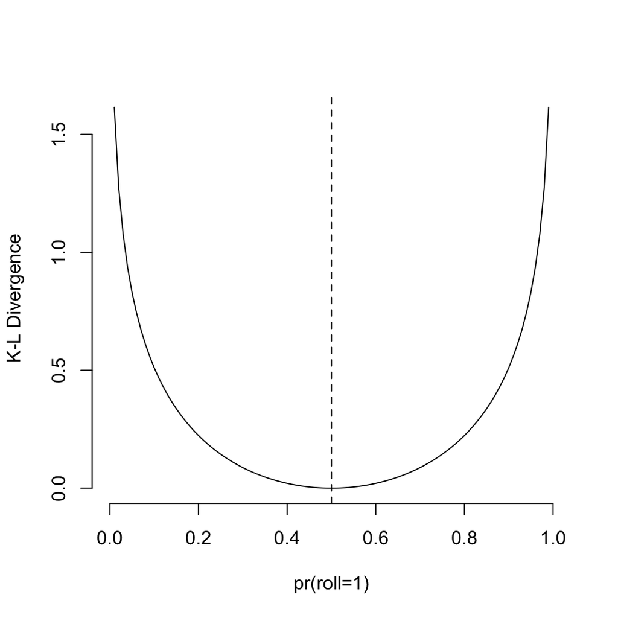

# The “true” model is unknown

- We never have access to the true model $p$ from this equation

$$D_{KL} = \sum_{i=1}^n p_i\log \left (\frac{p_i}{q_i} \right)$$

- We suspect our die is weighted from the rolls, but we don’t know the probs
- Instead we estimate them by performing an experiment (rolling the die) and building a model
- We have two competing hypotheses: call them $\theta_{map}$ and $\theta_{fair}$

$$\begin{aligned}
D_{KL, \theta_{map}} & = \sum_{i=1}^n \theta_{true}\log
\frac{\theta_{true}}{\theta_{map}} \\
D_{KL, \theta_{fair}} & = \sum_{i=1}^n
\theta_{true}\log \frac{\theta_{true}}{\theta_{fair}} \\
\end{aligned}$$

- $\theta_{true}$ cancels!
- We can compare the models’ relative performance without knowing anything about $\theta_{true}$

```r
log_likelihood = function(prob1, rolls)
    sum(dmultinom(table(rolls), prob = c(prob1, rep((1-prob1)/5, 5)),
                  log=TRUE))
log_posterior = function(prob1, rolls) {
    # a priori we expect 1 one and 5 not-ones
    log_likelihood(prob1, rolls) + dbeta(prob1, 1, 5, log=TRUE)
}

map = optim(pr_fair[1], method="Brent", log_posterior, rolls=rolls,
            control=list(fnscale=-1), lower=0, upper=1)
## no prior, for comparison
mle = optim(pr_fair[1], method="Brent", log_likelihood, rolls=rolls,
            control=list(fnscale=-1), lower=0, upper=1)
prs_map = c(map$par, rep((1-map$par)/5, 5))
prs_mle = c(mle$par, rep((1-mle$par)/5, 5))
round(cbind(
    observed = table(rolls)/sum(table(rolls)),
    map = prs_map,
    mle = prs_mle
), 2)
```

```
##   observed  map mle
## 1      0.5 0.36 0.5
## 2      0.1 0.13 0.1
## 3      0.1 0.13 0.1
## 4      0.1 0.13 0.1
## 5      0.1 0.13 0.1
## 6      0.1 0.13 0.1
```

# Deviance

- We can compare the models’ relative performance without knowing anything about $\theta_{true}$
- We just need to know the entropy of each model: $H_{\theta} = -\mathbb{E}\left [\log pr \left(x | \theta \right) \right ]$
- **Deviance** is an estimate of the entropy of a model:

$$D = -2 \sum \log pr \left(x | \theta \right)$$

- This is simply twice the log liklihood

```r
Dmap = -2 * log_likelihood(prs_map[1], rolls)
Dfair = -2 * log_likelihood(pr_fair[1], rolls)
Dmle = -2 * log_likelihood(prs_mle[1], rolls)

round(c(map = Dmap,mle = Dmle, fair = Dfair), 3)
```

```
##    map    mle   fair
## 10.175  9.323 15.201
```

- The MAP estimate has lower deviance, meaning it will predict new observations better than the hypothesis that the die is fair
- The prior is very important!

# Information criteria

- Take two models, $\theta_1$ has one parameter, $\theta_2$ has two
- If the models are nested ($\theta_1$ is a subset of $\theta_2$)
- $D_1$ will always be greater than $D_2$
  - This is due to the increased flexibility gained by adding parameters
- Thus we need a way of estimating *out-of-sample* deviance
  - How well do the models fit data that were not used for calibration
- Information criteria approximate this by penalizing models for complexity

$$\mathrm{AIC} = 2k - D\left [ \mathbb{E} \left (\theta \right )
\right ]$$

# AIC for the Tsuga model

- Last time, we had three varieties of models for the effect of precipitation on *Tsuga* mortality.
- We add a fourth here, with partial pooling but only for intercepts
  1. Completely pooled
  2. Unpooled intercepts (one intercept per year)
  3. Partially pooled intercepts & slopes (hierarchical model)

```r
tsuga_unpooled = stan_model("stan/tsuga_unpooled.stan")
tsuga_pooled = stan_model("stan/tsuga_pooled.stan")
tsuga_ppool = stan_model("stan/tsuga_ppool.stan")
tsuga_int_ppool = stan_model("stan/tsuga_int_ppool.stan")
```

# AIC for the Tsuga model

```stan
generated quantities {
    real deviance = 0;
    vector [n] loglik;
    for (i in 1:n) {
        loglik[i] = binomial_lpmf(died[i] | n_trees[i], p[i]);
        deviance += loglik[i];
    }
    deviance = -2 * deviance;
}
```

# AIC for the Tsuga model

```r
library(rstan)
map_up = optimizing(tsuga_unpooled, standat)
map_p = optimizing(tsuga_pooled, standat)
k1 = sum(grepl("^[a|b]", names(map_p$par)))  # 2 parameters
k2 = sum(grepl("^[a|b]", names(map_up$par)))  # 17 parameters
aic = c(2*k1 - map_up$par["deviance"], 2*k2 - map_p$par["deviance"])
res = rbind(aic, aic - min(aic)); rownames(res) = c("AIC", "delta"); colnames(res) = c("Pooled", "Unpooled")
res
```

```
##            Pooled  Unpooled
## AIC   -5840.79044 -5865.183
## delta    24.39306     0.000
```

- AIC prefers the more complex model:
  - Priors must be uninformative or totally overwhelmed by the data
  - Posterior must be multivariate normal
  - Sample size must be very large relative to the number of parameters (n > ~25*k)
- Moreover, AIC not well-defined for the hierarchial model
  - Parameters are not independent, so the model is less “complex” than the unpooled

# Deviance information critereon

- Bayesian models often have difficult-to-estimate numbers of parameters
- We can instead use posterior samples to approximate model complexity
  - How much to models differ from the “best” model, on average

```r
fit_up = sampling(tsuga_unpooled, standat, iter=5000, refresh=0, chains=1)
fit_p = sampling(tsuga_pooled, standat, iter=5000, refresh=0, chains=1)
fit_pp = sampling(tsuga_ppool, standat, iter=5000, refresh=0, chains=1)
fit_ipp = sampling(tsuga_int_ppool, standat, iter=5000, refresh=0, chains=1)

## note for the hierarchical model, a MAP is hard to find,
## here we use the min deviance as a quick and dirty estimate
## a better estimate is to compute the mean of all parameters, then
## compute the deviance with those values
pd = c(Pooled = mean(as.matrix(fit_p, pars="deviance")) - map_up$par["deviance"],
    Unpooled = mean(as.matrix(fit_up, pars="deviance")) - map_p$par["deviance"],
    Hierarchical = mean(as.matrix(fit_pp, pars="deviance")) - min(as.matrix(fit_pp, pars="deviance")),
    Hierarchical_intercept = mean(as.matrix(fit_ipp, pars="deviance")) - min(as.matrix(fit_ipp, pars="deviance")))
dic = 1*pd + c(map_up$par["deviance"], map_p$par["deviance"], min(as.matrix(fit_pp, pars="deviance")),
             min(as.matrix(fit_ipp, pars="deviance")))
dic = rbind(dic, dic - min(dic)); rownames(dic) = c("DIC", "delta")
dic
```

```
##       Pooled.deviance Unpooled.deviance Hierarchical Hierarchical_intercept
## DIC         5901.3308         5860.4609     5755.037              5872.4761
## delta        146.2942          105.4243        0.000               117.4395
```

# Log predictive pointwise density

- For real models, DIC has some problems
  - assumes posterior is multivariate normal
  - only assesses the “best” fit, doesn’t fully use the posterior
  - these can strongly influence inference, as well will see
- Instead of considering deviance of each model, we can consider the probability of each *data point*
  - This is closely related (but more fine-grained) to the penalty applied for DIC
  - Instead of averaging within models, we average for each point across $S$ posterior samples

$$\mathrm{lppd} = \sum_{i=1}^n \log \frac{1}{S} \sum_{j=1}^S pr(y_i |
\theta_j)$$

# Cross validation

- To best understand model performance, we should compare *out-of-sample*
- Holdout/validation dataset
  - separate, independent dataset not used for calibration
- k-fold
  - separate model into k “folds”
  - For each fold, fit the model to all data not in fold
  - validate against model in fold
  - best model has best average performace across all folds
- LOO
  - For $n$ data points, you fit $n$ models
  - Each time, you leave out one data point for validation

# LOO

- We can use the lppd to approximate LOO without the cost of fitting $n$ models
- Conceptually, AIC and DIC are attempts at *approximating* LOO
- WAIC (Widely applicable information criterion) extends this, using lppd instead of deviance

# LOO

- We can use the lppd to approximate LOO without the cost of fitting $n$ models
- Conceptually, AIC and DIC are attempts at *approximating* LOO
- WAIC (Widely applicable information criterion) extends this, using lppd instead of deviance
  - It is pointwise, so it approximates the cost to model fitting of leaving out each point
  - Averaged across the entire posterior

# LOO

- We can use the lppd to approximate LOO without the cost of fitting $n$ models
- Conceptually, AIC and DIC are attempts at *approximating* LOO
- WAIC (Widely applicable information criterion) extends this, using lppd instead of deviance
  - It is pointwise, so it approximates the cost to model fitting of leaving out each point
  - Averaged across the entire posterior
- Another technique, *importance sampling*, can directly approximate LOO
  - These methods don’t always work, but when they doo, LOO/WAIC provide more robust estimates than DIC/AIC

# LOO for trees

Package `loo` can estimate LOO-IC and WAIC for us. All that is needed is to compute the lpd (log pointwise density) in your Stan model.

```stan
generated quantities {
    vector [n] loglik; // vector, one per data point, because this is the pointwise density
    for (i in 1:n) {
        // here change binomial to whatever likelihood function applies to the model
        // lpmf: "log probability mass function"
        // for continuous distributions, use lpdf, e.g., normal_lpdf
        loglik[i] = binomial_lpmf(died[i] | n_trees[i], p[i]);
    }
}
```

# LOO for trees

```r
## put all models into a list for convenience when doing repeated operations
fits = list(unpooled=fit_up, pooled=fit_p, hierarchical=fit_pp, hierarchical_int=fit_ipp)

## get a loo object for each model
loos = lapply(fits, loo, pars="loglik")

loos$unpooled
```

```
##
## Computed from 2500 by 1406 log-likelihood matrix
##
##          Estimate    SE
## elpd_loo  -2965.5 134.2
## p_loo        63.8   7.0
## looic      5931.0 268.5
## ------
## Monte Carlo SE of elpd_loo is NA.
##
## Pareto k diagnostic values:
##                          Count Pct.    Min. n_eff
## (-Inf, 0.5]   (good)     1394  99.1%   178
##  (0.5, 0.7]   (ok)          5   0.4%   141
##    (0.7, 1]   (bad)         5   0.4%   39
##    (1, Inf)   (very bad)    2   0.1%   15
## See help('pareto-k-diagnostic') for details.
```

```r
print(loo_compare(loos), simplify = FALSE)
```

```
##                  elpd_diff se_diff elpd_loo se_elpd_loo p_loo   se_p_loo
## hierarchical         0.0       0.0 -2918.8    133.0        79.0     9.2
## pooled             -37.2      24.2 -2956.0    130.4        10.7     1.3
## hierarchical_int   -41.2      22.0 -2960.0    133.2        46.6     5.0
## unpooled           -46.7      23.0 -2965.5    134.2        63.8     7.0
##                  looic   se_looic
## hierarchical      5837.6   265.9
## pooled            5912.1   260.7
## hierarchical_int  5920.0   266.3
## unpooled          5931.0   268.5
```

# Model weights

- LOO/W/A/D IC can choose a “best” model for us
- But all models are wrong, and even models that aren’t the best contain information
- Akaike weights are a computationally simple way of performing mulimodel inference
  - Roughly speaking, $w_i$ is the probability that model $i$ is the best model in the set of $m$ models
  - if using `loo`’s `elpd_diff`, can omit the $-\frac{1}{2}$

$$w_i = \frac{e^{-\frac{1}{2}\Delta \mathrm{*IC}_i}}
{\sum_{j=1}^m e^{-\frac{1}{2}\Delta \mathrm{*IC}_j}}$$

```r
looics = sapply(loos, function(x) x$estimates['looic', 'Estimate'])
delta_looic = looics - min(looics)
wi = exp(-0.5*delta_looic) / sum(exp(-0.5*delta_looic))
round(rbind(looic = looics, dlooic = delta_looic, weight = wi), 2)
```

```
##        unpooled  pooled hierarchical hierarchical_int
## looic   5930.97 5912.09       5837.6          5920.05
## dlooic    93.37   74.49          0.0            82.45
## weight     0.00    0.00          1.0             0.00
```

# Weights for multimodel inference

- Akaike weights can help us decide how much to trust a single ‘best’ model
- They underestimate information contained in the posteriors of the worse models
- A more Bayesian approach is to make predictions, averaging the uncertainty from all models
- For this we use **stacking weights**, which choose weights based on maximising the `elpd` from LOO

```r
wts = loo_model_weights(loos)
wts
## Method: stacking
## ------
##                  weight
## unpooled         0.159
## pooled           0.245
## hierarchical     0.596
## hierarchical_int 0.000
```

# Bayesian model averaging

- We can produce a posterior predictive distribution in Stan

```stan
generated quantities {
    vector [n] loglik; // vector, one per data point, because this is the pointwise density
    int ppd_died [n]; // predicted number of trees dying at each point in the original dataset
    for (i in 1:n) {
        // here change binomial to whatever likelihood function applies to the model
        // lpmf: "log probability mass function"
        // for continuous distributions, use lpdf, e.g., normal_lpdf
        loglik[i] = binomial_lpmf(died[i] | n_trees[i], p[i]);
        ppd_died[i] = binomial_rng(10, p[i]); // here I give a ppd assuming a sample size of 10 trees
    }
}
```

- Then apply the weights to our predictions

```r
ppd = lapply(fits, as.matrix, pars="ppd_died")
weighted_ppd = Map(`*`, ppd, wts)
avg_predictions = Reduce(`+`, weighted_ppd)

## now get some quantile intervals, put them alongside the original values and the temperature
quants = lapply(ppd, function(x) cbind(data.table(t(apply(x, 2, quantile, c(0.5, 0.05, 0.95)))), tsuga))
quants$ensemble = cbind(data.table(t(apply(avg_predictions, 2, quantile, c(0.5, 0.05, 0.95)))), tsuga)
quants = rbindlist(quants, idcol="model")
colnames(quants)[2:4] = c("median", "lower", "upper")

pl = ggplot(quants[year %in% c(2005:2008, 2011:2012)], aes(x=tot_annual_pp, y = median/10, colour = model)) +
    geom_line() +
    geom_ribbon(aes(x=tot_annual_pp, ymin= lower/10, ymax=upper/10, fill = model), alpha = 0.5, show.legend = FALSE) +
    facet_grid(model ~ year) + theme_minimal() + geom_point(aes(x=tot_annual_pp, y = died/n), size=0.6) +
    xlab("Total Annual Precipitation (mm)") + ylab("Proportion dying")
```

# Bayesian model averaging results

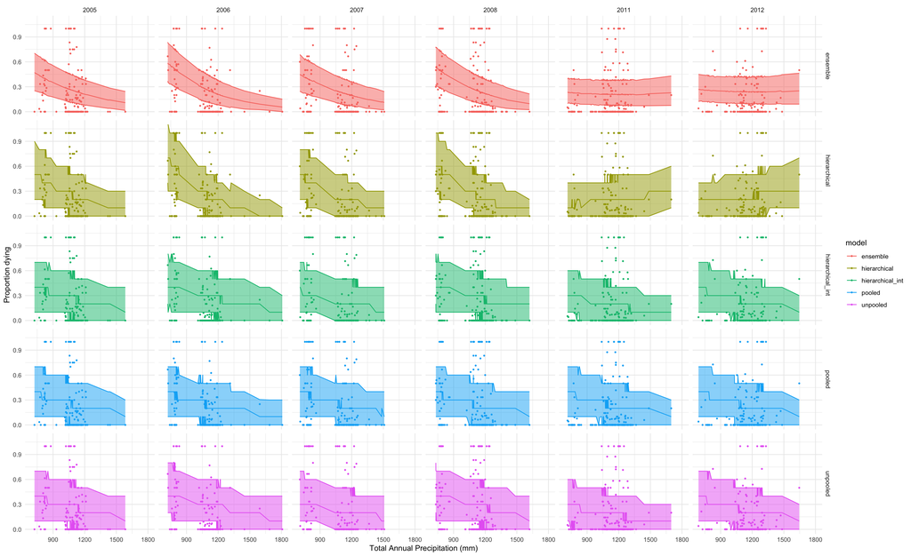